# Week 11 Weekend Homework | Text Mining

```r
library(janeaustenr)
library(tidyverse)
library(tidytext)
library(textdata)
```

# MVP

Using the dataset austen_books() from the package janeaustenr:

1. Find the most common words in both Pride & Prejudice and Sense & Sensibility.

```r
# Change Pride & Prejudice into a tibble of words;

pride_book <- tibble(
  id = 1:length(prideprejudice),
  text = prideprejudice) %>%
  unnest_tokens(word, text)
pride_book %>%
  count(word, sort = TRUE)
```

| word | n |
| --- | --- |
| the | 4331 |
| to | 4162 |
| of | 3610 |
| and | 3585 |
| her | 2203 |
| i | 2065 |
| a | 1954 |
| in | 1880 |
| was | 1843 |
| she | 1695 |

[output cut: 990 more lines]

```r
# and repeat for Sense & Sensibility

sense_book <- tibble(
  id = 1:length(sensesensibility),
  text = sensesensibility) %>%
  unnest_tokens(word, text)
sense_book %>%
  count(word, sort = TRUE)
```

| word | n |
| --- | --- |
| to | 4116 |
| the | 4105 |
| of | 3571 |
| and | 3490 |
| her | 2543 |
| a | 2092 |
| i | 1998 |
| in | 1979 |
| was | 1861 |
| it | 1755 |

[output cut: 990 more lines]

```r
NA
NA
```

The most common words in “Pride and Prejudice” and “Sense and Sensibility” are stop words.

2. Find the most common words in both Pride & Prejudice and Sense & Sensibility, not including stop words.

Stop words can be removed by anti-joining the `stop_words` lexicon;

```r
pride_book %>%
  anti_join(stop_words, by = "word") %>%
  count(word, sort = TRUE)
```

| word | n |
| --- | --- |
| elizabeth | 597 |
| darcy | 373 |
| bennet | 294 |
| miss | 283 |
| jane | 264 |
| bingley | 257 |
| time | 203 |
| lady | 183 |
| sister | 180 |
| wickham | 162 |

[output cut: 990 more lines]

```r
sense_book %>%
  anti_join(stop_words, by = "word") %>%
  count(word, sort = TRUE)
```

| word | n |
| --- | --- |
| elinor | 623 |
| marianne | 492 |
| time | 239 |
| dashwood | 231 |
| sister | 229 |
| edward | 220 |
| mother | 213 |
| miss | 210 |
| jennings | 199 |
| willoughby | 181 |

[output cut: 990 more lines]

3. Find the most common sentiment words in both Pride & Prejudice and Sense & Sensibility.

Using the “bing” lexicon;

```r
pride_sentiment <- pride_book %>%
  inner_join(get_sentiments("bing"), by = "word") %>%  # inner_join to avoid NAs
  count(word, sort = TRUE)
pride_sentiment
```

| word | n |
| --- | --- |
| miss | 283 |
| well | 224 |
| good | 200 |
| great | 142 |
| enough | 106 |
| better | 92 |
| love | 92 |
| pleasure | 92 |
| happy | 83 |
| like | 77 |

[output cut: 990 more lines]

The top word is “miss”, but this is a term of address rather than something having been “missed”, so can be removed;

```r
pride_sentiment <- pride_book %>%
  filter(word!= "miss") %>%
  inner_join(get_sentiments("bing"), by = "word") %>%  # inner_join to avoid NAs
  count(word, sort = TRUE)
pride_sentiment
```

| word | n |
| --- | --- |
| well | 224 |
| good | 200 |
| great | 142 |
| enough | 106 |
| better | 92 |
| love | 92 |
| pleasure | 92 |
| happy | 83 |
| like | 77 |
| happiness | 72 |

[output cut: 990 more lines]

…and the same for “Sense and Sensibility”…

```r
sense_sentiment <- sense_book %>%
  filter(word != "miss") %>%
  inner_join(get_sentiments("bing"), by = "word") %>%
  count(word, sort = TRUE)
sense_sentiment
```

| word | n |
| --- | --- |
| well | 240 |
| good | 177 |
| great | 149 |
| enough | 103 |
| happy | 100 |
| like | 83 |
| affection | 79 |
| better | 78 |
| love | 77 |
| poor | 71 |

[output cut: 990 more lines]

# 2 Extension

Taking your results above. Can you create a plot which visualises the differences between the books?

Probably best to run a comparison of sentences, rather than words;

[output not shown]

[output cut: 990 more lines]

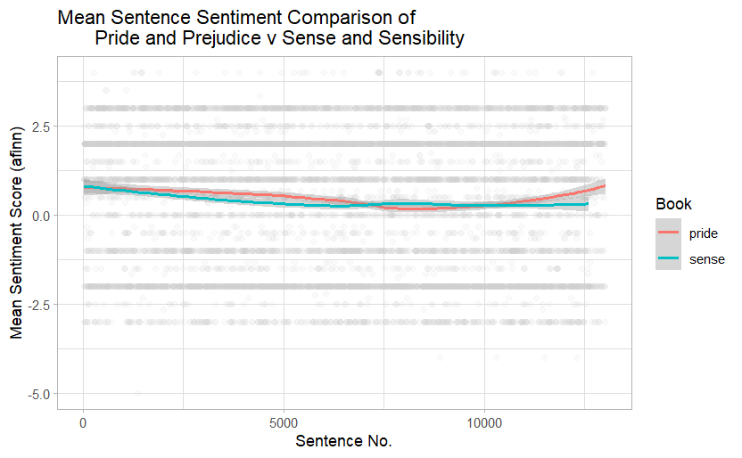

```r
sentiment_scores %>%
  ggplot() +
  aes(x = sentence, y = mean_sentiment, colour = book) +
  geom_point(colour = "grey80", alpha = 0.1) +
  geom_smooth(method = "loess") +
  theme_light() +
  labs(title = "Mean Sentence Sentiment Comparison of
       Pride and Prejudice v Sense and Sensibility",
       x = "Sentence No.",
       y = "Mean Sentiment Score (afinn)",
       colour = "Book")
```

The plot shows that both books score very similar results for sentiment on average, with Pride and Prejudice possibly having a happier ending than Sense and Sensibility. The mean remains above 0 for the duration of the books, so the good sentiments outweigh the bad.

Looking at total sentiment scores;

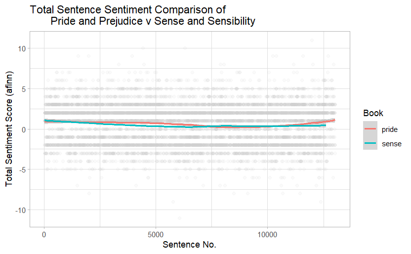

```r
sentiment_scores %>%
  ggplot() +
  aes(x = sentence, y = total_sentiment, colour = book) +
  geom_point(colour = "grey80", alpha = 0.1) +
  geom_smooth(method = "loess") +
  theme_light() +
  labs(title = "Total Sentence Sentiment Comparison of
       Pride and Prejudice v Sense and Sensibility",
       x = "Sentence No.",
       y = "Total Sentiment Score (afinn)",
       colour = "Book")
```

The total sentiment score between the books is closer, but once agani Pride and Prejudice appears to finish on a slightly happier note.